# R Univariate and Bivariate analysis

Kevin Kilonzo

21/01/2022

R PROGRAMMING: UNIVARIATE AND BIVARIATE ANALYSIS 1- DEFINING THE QUESTION a) Specifying the question Performing EDA on the dataset provided

2. Defining the metric for success To be able to perform analysis on the dataset provided
3. Understanding the context The IP advertising dataset gives information on the ad clicks of the respondents and whether they click on the ads or not
4. Recording the experimental design 1. Defining the question 2. Instaling and loading the libraries 3. Loading the dataset 4. Cleaning the dataset 5. Performing univariate analysis 6. Performing bivariate analysis
5. Data relevance * Daiy time spent on site - Time spent on the site in question daily * Age - Age of the respondents * Area income - Income of the area where the respondent is accessing the site * Daily Internet usage - Time spent using the internet by the respondent daily * Ad topic line - The ad displayed to the respondent * City - the city the respondent is viewing rthe ad * Male - Whether respondent is male or not (1-Male , 0-Female) * Country - Country where the respondent is viewing the ad * Timestamp - Timestamp of the moment of viewing the ad * Clicked on ad - Whether the respondent clicked on the ad or not (1-Clicked, 0-Not clicked)

```r
 # Installing and loading libraries
#install.packages("r package",repo="https://github.com/Rdatatable/data.table")
library("data.table")

#install.packages("tidyverse")
library("tidyverse")
# Loading the dataset
data <- fread("http://bit.ly/IPAdvertisingData")
```

3.LOAD AND CHECK THE DATASET

```r
# Preview of the dataset
head(data)
```

```
##    Daily Time Spent on Site Age Area Income Daily Internet Usage
## 1:                    68.95  35    61833.90               256.09
## 2:                    80.23  31    68441.85               193.77
## 3:                    69.47  26    59785.94               236.50
## 4:                    74.15  29    54806.18               245.89
## 5:                    68.37  35    73889.99               225.58
## 6:                    59.99  23    59761.56               226.74
##                            Ad Topic Line           City Male    Country
## 1:    Cloned 5thgeneration orchestration    Wrightburgh    0    Tunisia
## 2:    Monitored national standardization      West Jodi    1      Nauru
## 3:      Organic bottom-line service-desk       Davidton    0 San Marino
## 4: Triple-buffered reciprocal time-frame West Terrifurt    1      Italy
## 5:         Robust logistical utilization   South Manuel    0    Iceland
## 6:       Sharable client-driven software      Jamieberg    1     Norway
##              Timestamp Clicked on Ad
## 1: 2016-03-27 00:53:11             0
## 2: 2016-04-04 01:39:02             0
## 3: 2016-03-13 20:35:42             0
## 4: 2016-01-10 02:31:19             0
## 5: 2016-06-03 03:36:18             0
## 6: 2016-05-19 14:30:17             0
```

```r
# Show dataframe
view(data)
# Check datatypes
str(data)
```

```
## Classes 'data.table' and 'data.frame':   1000 obs. of  10 variables:
##  $ Daily Time Spent on Site: num  69 80.2 69.5 74.2 68.4 ...
##  $ Age                     : int  35 31 26 29 35 23 33 48 30 20 ...
##  $ Area Income             : num  61834 68442 59786 54806 73890 ...
##  $ Daily Internet Usage    : num  256 194 236 246 226 ...
##  $ Ad Topic Line           : chr  "Cloned 5thgeneration orchestration" "Monitored national standardization" "Organic bottom-line service-desk" "Triple-buffered reciprocal time-frame" ...
##  $ City                    : chr  "Wrightburgh" "West Jodi" "Davidton" "West Terrifurt" ...
##  $ Male                    : int  0 1 0 1 0 1 0 1 1 1 ...
##  $ Country                 : chr  "Tunisia" "Nauru" "San Marino" "Italy" ...
##  $ Timestamp               : POSIXct, format: "2016-03-27 00:53:11" "2016-04-04 01:39:02" ...
##  $ Clicked on Ad           : int  0 0 0 0 0 0 0 1 0 0 ...
##  - attr(*, ".internal.selfref")=<externalptr>
```

```r
# Check rows and columns
dim(data)
```

```
## [1] 1000   10
```

The data has 1000 rows and 10 columns

3. CLEANING THE DATASET

```r
# Checking for null values
# Checking missing values in columns
colSums(is.na(data))
```

```
## Daily Time Spent on Site                      Age              Area Income
##                        0                        0                        0
##     Daily Internet Usage            Ad Topic Line                     City
##                        0                        0                        0
##                     Male                  Country                Timestamp
##                        0                        0                        0
##            Clicked on Ad
##                        0
```

```r
# Checking for duplicates
dupli <- data[duplicated(data),]
dupli
```

```
## Empty data.table (0 rows and 10 cols): Daily Time Spent on Site,Age,Area Income,Daily Internet Usage,Ad Topic Line,City...
```

```r
# Checking for outliers
nums <- select_if(data, is.numeric)
head(nums)
```

```
##    Daily Time Spent on Site Age Area Income Daily Internet Usage Male
## 1:                    68.95  35    61833.90               256.09    0
## 2:                    80.23  31    68441.85               193.77    1
## 3:                    69.47  26    59785.94               236.50    0
## 4:                    74.15  29    54806.18               245.89    1
## 5:                    68.37  35    73889.99               225.58    0
## 6:                    59.99  23    59761.56               226.74    1
##    Clicked on Ad
## 1:             0
## 2:             0
## 3:             0
## 4:             0
## 5:             0
## 6:             0
```

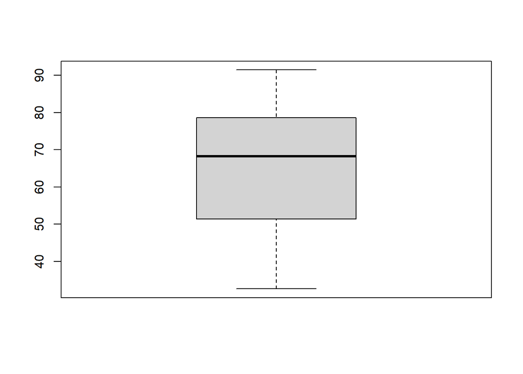

```r
boxplot(nums$`Daily Time Spent on Site`)
```

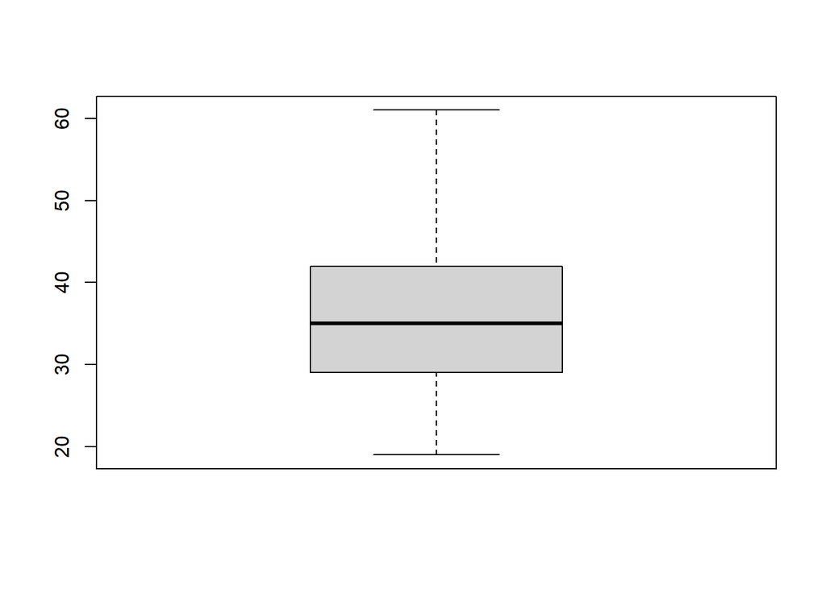

```r
boxplot(nums$Age)
```

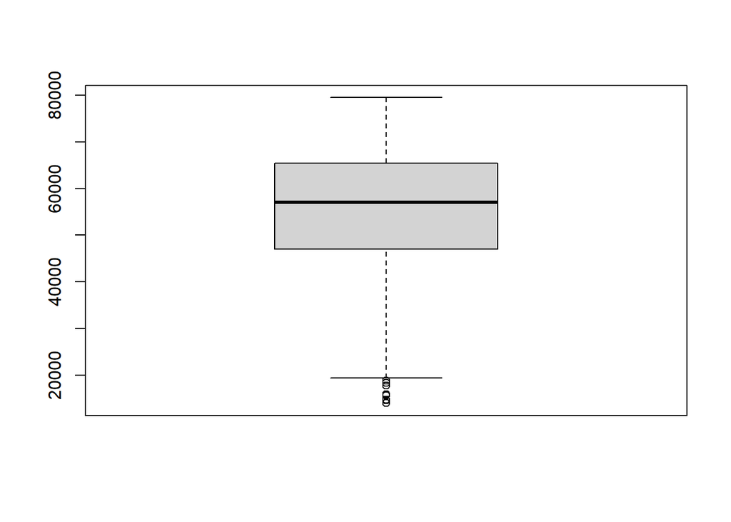

```r
boxplot(nums$`Area Income`)
```

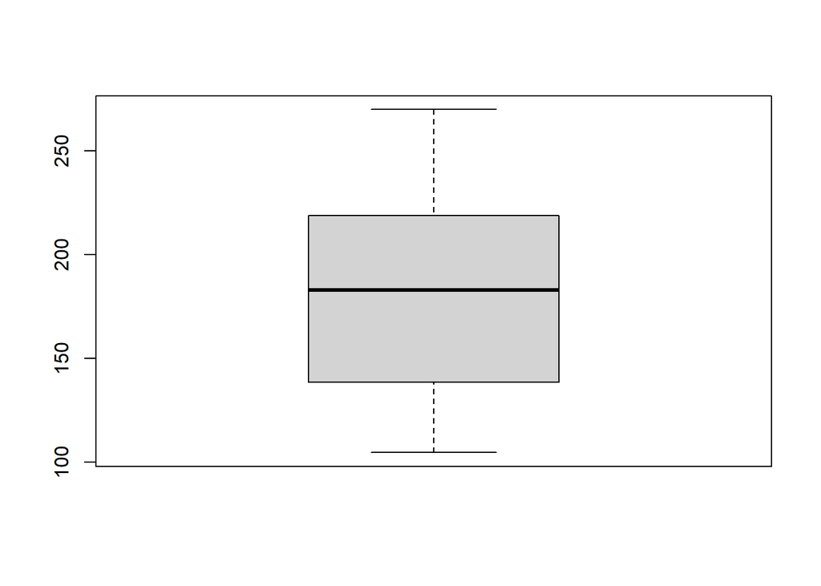

```r
boxplot(data$`Daily Internet Usage`)
```

The other two remaining numerical columns (Male, Clicked on ad ) are binary so no outliers Outliers found in area income are expected as they are on the lower side which is possible with people with low or no incomes

4. UNIVARIATE ANALYSIS

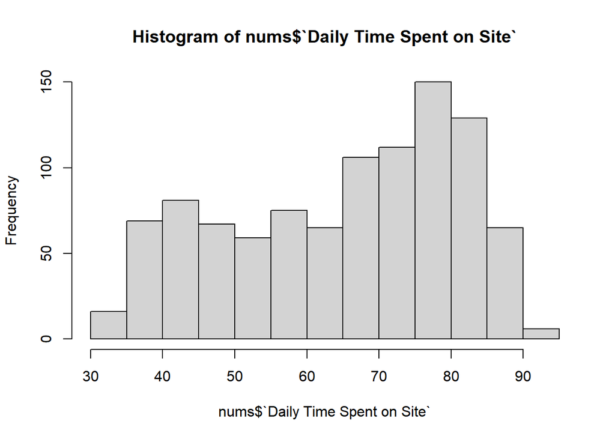

```r
# Mode function for getting mode
getmode <- function(v)
{uniqv <- unique(v)
uniqv[which.max(tabulate(match(v,uniqv)))]}

# Daily time spent on site colummn
mean_daily <- mean(nums$`Daily Time Spent on Site`)
median_daily <- median(nums$`Daily Time Spent on Site`)
mode_daily <- getmode(nums$`Daily Time Spent on Site`)
quartile_daily <- quantile(nums$`Daily Time Spent on Site`)
range_daily <- range(nums$`Daily Time Spent on Site`)
std_dev_daily <- sd(nums$`Daily Time Spent on Site`)
hist(nums$`Daily Time Spent on Site`)
```

```r
# Print outs
# mean_daily
mean_daily
```

```
## [1] 65.0002
```

```r
# median_daily
median_daily
```

```
## [1] 68.215
```

```r
# mode_daily
mode_daily
```

```
## [1] 62.26
```

```r
# quartile_daily
quartile_daily
```

```
##      0%     25%     50%     75%    100%
## 32.6000 51.3600 68.2150 78.5475 91.4300
```

```r
# range_daily
range_daily
```

```
## [1] 32.60 91.43
```

```r
# std_dev_daily
std_dev_daily
```

```
## [1] 15.85361
```

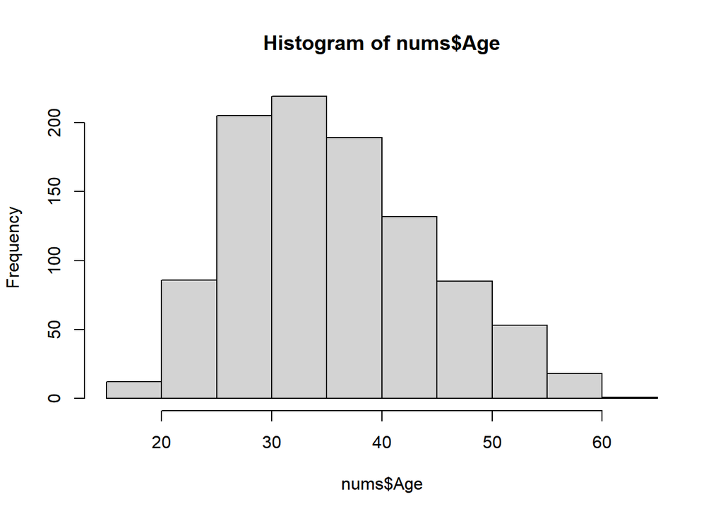

```r
# Age column
mean_age <- mean(nums$Age)
median_age <- median(nums$Age)
mode_age <- getmode(nums$Age)
quartile_age <- quantile(nums$Age)
range_age <- range(nums$Age)
std_dev_age <- sd(nums$Age)
hist(nums$Age)
```

```r
# Print outs
# mean_age
mean_age
```

```
## [1] 36.009
```

```r
# median_age
median_age
```

```
## [1] 35
```

```r
# mode_age
mode_age
```

```
## [1] 31
```

```r
# quartile_age
quartile_age
```

```
##   0%  25%  50%  75% 100%
##   19   29   35   42   61
```

```r
# range_age
range_age
```

```
## [1] 19 61
```

```r
# std_dev_age
std_dev_age
```

```
## [1] 8.785562
```

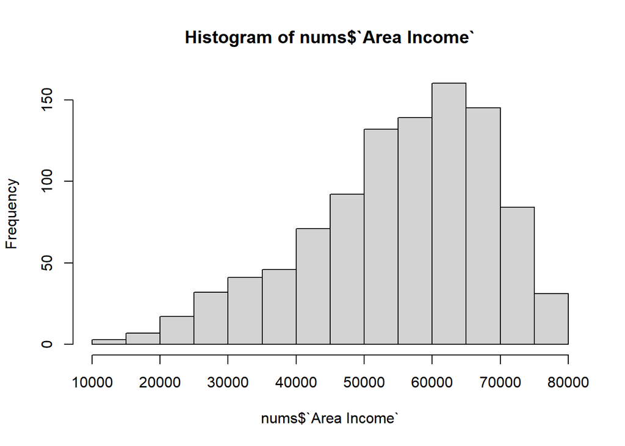

```r
# Area income column
mean_income <- mean(nums$`Area Income`)
median_income <- median(nums$`Area Income`)
mode_income <- getmode(nums$`Area Income`)
quartile_income <- quantile(nums$`Area Income`)
range_income <- range(nums$`Area Income`)
std_dev_income <- sd(nums$`Area Income`)
hist(nums$`Area Income`)
```

```r
# Print outs
# mean_income
mean_income
```

```
## [1] 55000
```

```r
# median_income
median_income
```

```
## [1] 57012.3
```

```r
# mode_income
mode_income
```

```
## [1] 61833.9
```

```r
# quartile_income
quartile_income
```

```
##       0%      25%      50%      75%     100%
## 13996.50 47031.80 57012.30 65470.64 79484.80
```

```r
# range_income
range_income
```

```
## [1] 13996.5 79484.8
```

```r
# std_dev_income
std_dev_income
```

```
## [1] 13414.63
```

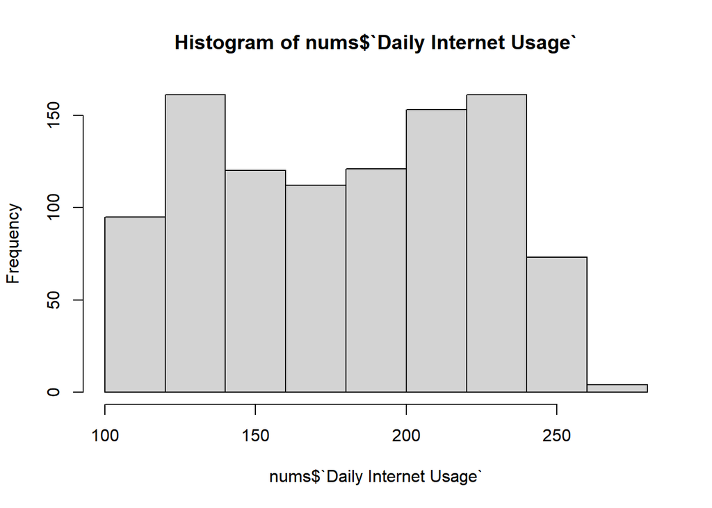

```r
# Daily internet usage column
mean_usage <- mean(nums$`Daily Internet Usage`)
median_usage <- median(nums$`Daily Internet Usage`)
mode_usage <- getmode(nums$`Daily Internet Usage`)
quartile_usage <- quantile(nums$`Daily Internet Usage`)
range_usage <- range(nums$`Daily Internet Usage`)
std_dev_usage <- sd(nums$`Daily Internet Usage`)
hist(nums$`Daily Internet Usage`)
```

```r
# Print outs
# mean_usage
mean_usage
```

```
## [1] 180.0001
```

```r
# median_usage
median_usage
```

```
## [1] 183.13
```

```r
# mode_usage
mode_usage
```

```
## [1] 167.22
```

```r
# quartile_usage
quartile_usage
```

```
##       0%      25%      50%      75%     100%
## 104.7800 138.8300 183.1300 218.7925 269.9600
```

```r
# range_usage
range_usage
```

```
## [1] 104.78 269.96
```

```r
# std_dev_usage
std_dev_usage
```

```
## [1] 43.90234
```

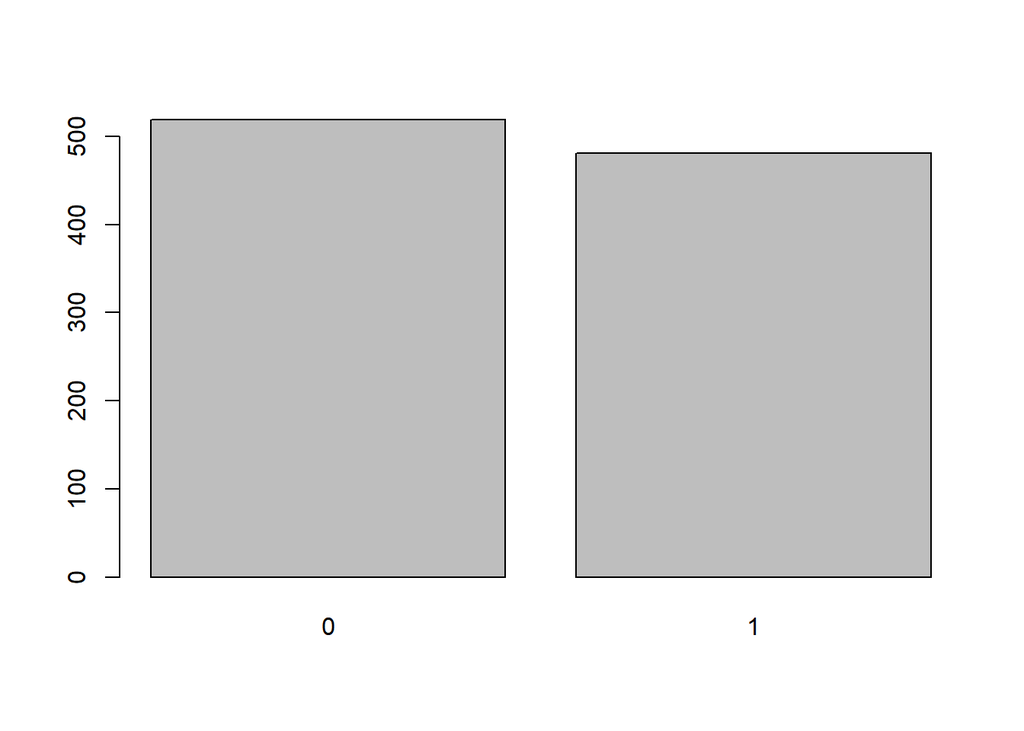

```r
# Bar graphs for the binary columns
# Assigning cols to variables
click <- nums$`Clicked on Ad`
gender <- nums$Male

# Frequency tables
freq_click <- table(click)
freq_gender <- table(gender)

# Plotting bar graphs
# Gender bargraph
barplot(freq_gender)
```

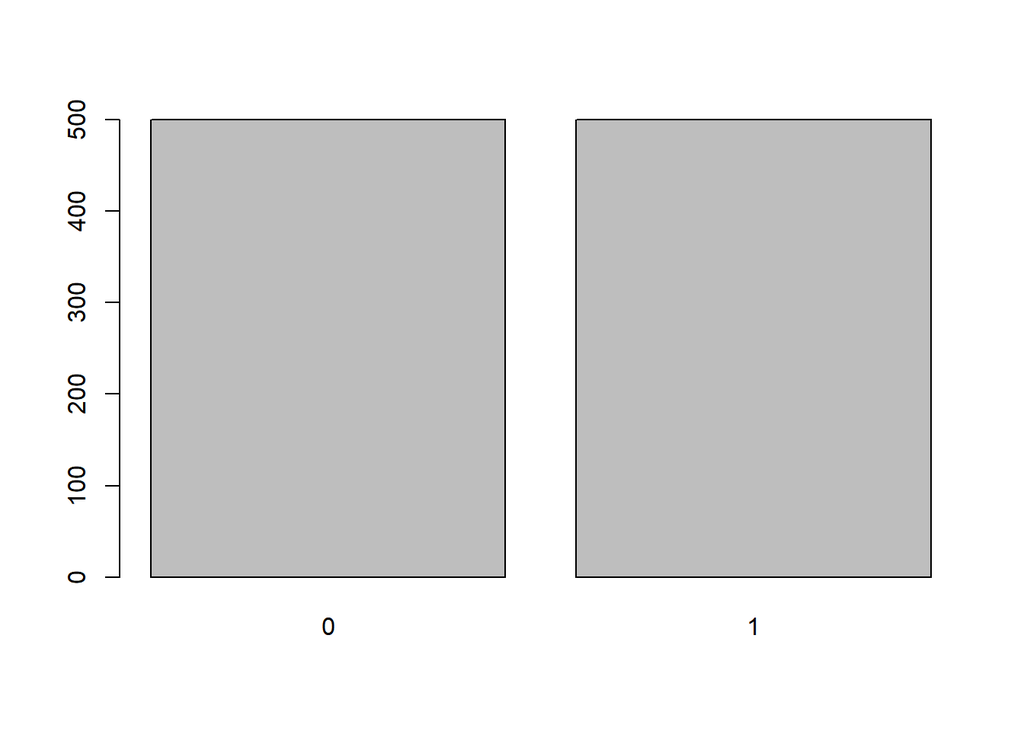

```r
# Ad clicks bar graph
barplot(freq_click)
```